# Where is the Money for Feminist Organizing? Survey for feminist, women’s rights and gender justice movements, groups and organizations

2024-07-19

#WITM follow up

**Database upload**

```r
# OPEN CSV file
witm <- read.csv2("Data/WITM_csv_0719.csv")

source(file="WITM_variables.R")
```

**-.-.-.-.-.-.-.-.-.-.-.-.-.-.-.-.-.-.-.-.-.-.-.-.-.-.-.-.-.-** Section 2: Financial Status **-.-.-.-.-.-.-.-.-.-.-.-.-.-.-.-.-.-.-.-.-.-.-.-.-.-.-.-.-.-**

Q10. What was the annual budget for your group, organization and/or movement in each of the following years in $USD?

Annual_budget

Percentage_2021

Percentage_2022

Percentage_2023

1. Zero budget

15.4

13.2

11.9

2. <5000

17.5

15.6

13.6

3. 5001-10000

12.3

12.0

12.4

4. 10001-30000

12.1

13.8

15.3

5. 30001 -50000

9.5

8.1

8.3

6. 50001 - 100000

8.5

10.7

10.9

7. 100001 - 250000

10.6

11.3

12.7

8. 250001 - 500000

6.1

6.1

5.9

1. 500001 - 1000000

2.7

3.6

3.1

10. 1000001 - 2000000

2.3

2.1

2.2

11. 2000001 - 4000000

1.1

1.6

1.9

12. > 4000001

1.9

2.0

1.9

**–Analysis notes———————————————————————–**

For a better analysis, income should be better grouped.

**————————————————————————————————**

**-.-.-.-.-.-.-.-.-.-.-.-.-.-.-.-.-.-.-.-.-.-.-.-.-.-.-.-.-.-** SECTION : EXTERNAL FOUNDING **-.-.-.-.-.-.-.-.-.-.-.-.-.-.-.-.-.-.-.-.-.-.-.-.-.-.-.-.-.-**

**External founding:**

Q13. Between 2021 and 2023, has your group, organization and/or movement received any external funding?

| External funding | n | porcentaje |
| --- | --- | --- |
| no | 162 | 27.5 |
| yes | 427 | 72.5 |

**–Analysis notes———————————————————————–**

The majority report having external funding but the value of those who do not is very high.

**————————————————————————————————**

**-.-.-.-.-.-.-.-.-.-.-.-.-.-.-.-.-.-.-.-.-.-.-.-.-.-.-.-.-.-**

**External funding by type of organisation**

| q13_ext_funding | Primary focus | Specific Projects | Other |
| --- | --- | --- | --- |
| yes | 74.9 | 62.5 | 70.2 |
| no | 25.1 | 37.5 | 29.8 |

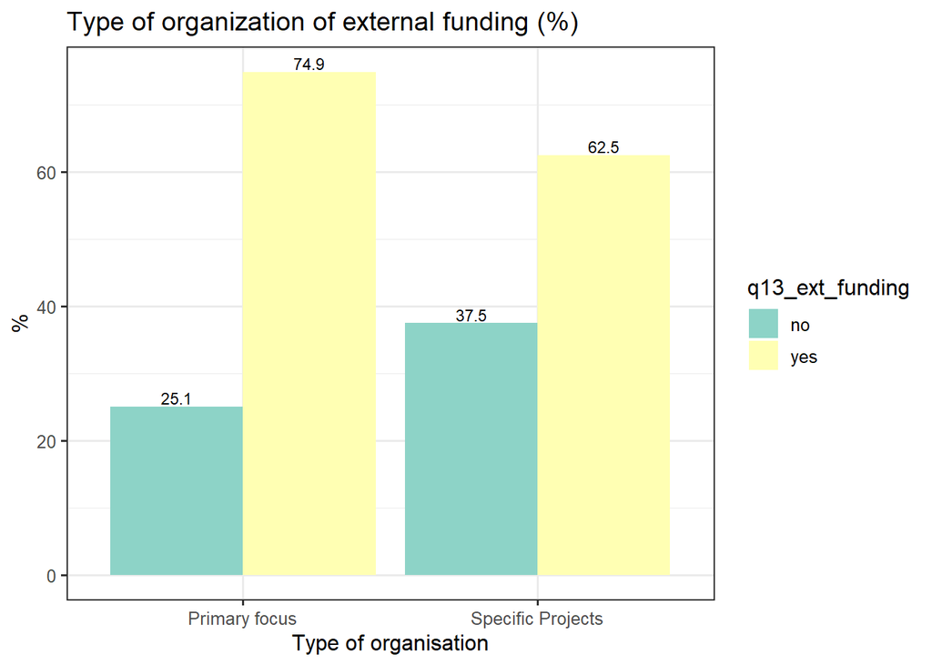

**–Analysis notes———————————————————————–**

Organizations that work on gender and feminist projects receive less external funding.

**————————————————————————————————**

**-.-.-.-.-.-.-.-.-.-.-.-.-.-.-.-.-.-.-.-.-.-.-.-.-.-.-.-.-.-**

**External funding by registration**

| q13_ext_funding | Registered | No registered | Other |
| --- | --- | --- | --- |
| yes | 78.2 | 46.7 | 47.1 |
| no | 21.8 | 53.3 | 52.9 |

```
## # A tibble: 6 × 3
## # Groups:   q5_registered [3]
##   q13_ext_funding q5_registered percentage
##   <chr>           <chr>              <dbl>
## 1 yes             Registered          78.2
## 2 no              Registered          21.8
## 3 no              No registered       53.3
## 4 yes             No registered       46.7
## 5 no              Other               52.9
## 6 yes             Other               47.1
```

```
## # A tibble: 4 × 3
## # Groups:   q5_registered [2]
##   q13_ext_funding q5_registered percentage
##   <chr>           <chr>              <dbl>
## 1 yes             Registered          78.2
## 2 no              Registered          21.8
## 3 no              No registered       53.3
## 4 yes             No registered       46.7
```

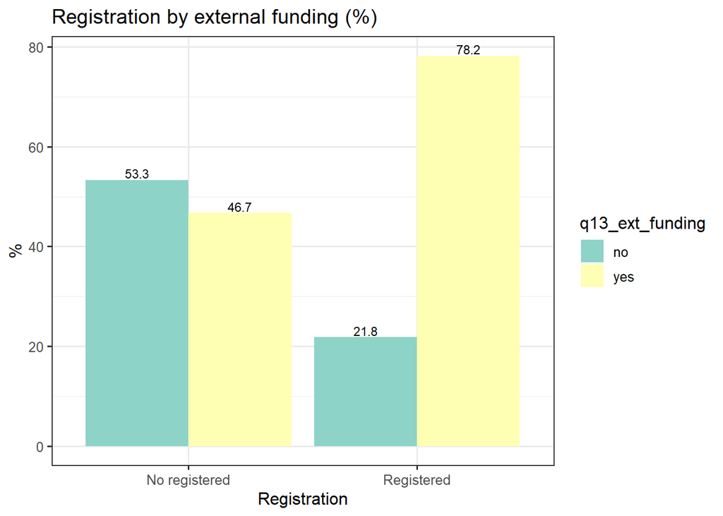

**–Analysis notes———————————————————————–**

Organizations that are not registered receive less frequent external financing

**————————————————————————————————**

**-.-.-.-.-.-.-.-.-.-.-.-.-.-.-.-.-.-.-.-.-.-.-.-.-.-.-.-.-.-**

**External funding by Geographic Scope**

```
## # A tibble: 12 × 3
## # Groups:   q6_geo_scope [6]
##    q13_ext_funding q6_geo_scope                            percentage
##    <chr>           <chr>                                        <dbl>
##  1 yes             Nationally                                    73.9
##  2 yes             Locally                                       67.6
##  3 no              Nationally                                    26.1
##  4 no              Locally                                       32.4
##  5 yes             Regionally                                    82.8
##  6 yes             Global                                        69.8
##  7 no              Global                                        30.2
##  8 no              Regionally                                    17.2
##  9 yes             Transnationally                               72.7
## 10 yes             Work from diaspora, refuge and/or exile       80
## 11 no              Transnationally                               27.3
## 12 no              Work from diaspora, refuge and/or exile       20
```

| q13_ext_funding | Nationally | Locally | Regionally | Global | Transnationally | Work from diaspora, refuge and/or exile |
| --- | --- | --- | --- | --- | --- | --- |
| yes | 73.9 | 67.6 | 82.8 | 69.8 | 72.7 | 80 |
| no | 26.1 | 32.4 | 17.2 | 30.2 | 27.3 | 20 |

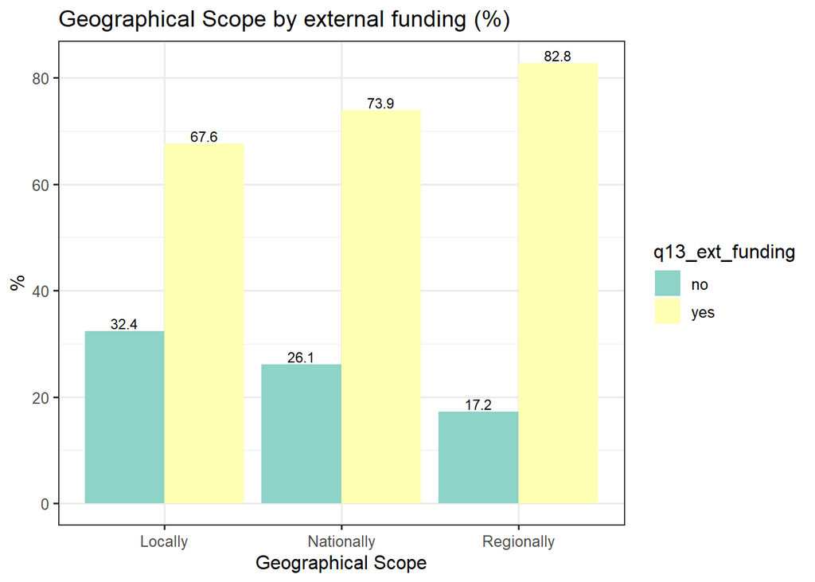

**–Analysis notes———————————————————————–**

This graph is very important and shows how local and national organizations have less access to external funding than regional ones. These groups are taken only because they are numerous, the rest will have to wait for more answers or be analyzed more carefully.

**————————————————————————————————**

**-.-.-.-.-.-.-.-.-.-.-.-.-.-.-.-.-.-.-.-.-.-.-.-.-.-.-.-.-.-**

**External funding by start of activities (year)**

```
## # A tibble: 10 × 3
## # Groups:   q9_year_formation_agrup [5]
##    q13_ext_funding q9_year_formation_agrup percentage
##    <chr>           <chr>                        <dbl>
##  1 yes             (2) From 2015 to 2020         71.1
##  2 yes             (4) From 2000 to 2009         82.2
##  3 yes             (3) From 2010 to 2014         76.4
##  4 yes             (5) Before 2000               87.7
##  5 no              (2) From 2015 to 2020         28.9
##  6 no              (1) 2021-2023                 56.3
##  7 yes             (1) 2021-2023                 43.7
##  8 no              (3) From 2010 to 2014         23.6
##  9 no              (4) From 2000 to 2009         17.8
## 10 no              (5) Before 2000               12.3
```

q13_ext_funding

2. From 2015 to 2020
4. From 2000 to 2009
3. From 2010 to 2014
5. Before 2000
1. 2021-2023

yes

71.1

82.2

76.4

87.7

43.7

no

28.9

17.8

23.6

12.3

56.3

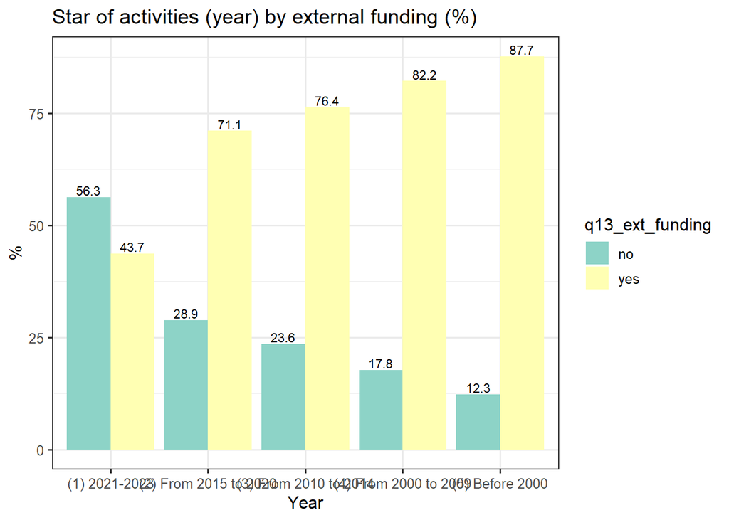

**–Analysis notes———————————————————————–**

**————————————————————————————————**

**-.-.-.-.-.-.-.-.-.-.-.-.-.-.-.-.-.-.-.-.-.-.-.-.-.-.-.-.-.-**

*Q14. Please indicate the percentage of external funding in your total annual budget for each year:

CONDITIONS: [Q14 filtered by Q13= YES]

| Range | Percentage_2023 | Percentage_2022 | Percentage_2021 |
| --- | --- | --- | --- |
| 0 | 2.8 | 6.7 | 12.9 |
| 10 | 7.0 | 7.1 | 9.7 |
| 20 | 4.9 | 7.9 | 5.5 |
| 30 | 6.8 | 6.4 | 5.5 |
| 40 | 4.2 | 3.6 | 4.0 |
| 50 | 5.9 | 4.8 | 6.0 |
| 60 | 5.6 | 4.0 | 5.0 |
| 70 | 6.6 | 7.1 | 5.5 |
| 80 | 11.2 | 8.8 | 6.0 |
| 90 | 14.3 | 15.5 | 14.9 |
| 100 | 30.7 | 28.1 | 25.3 |